# Context-dependent activity of enhancer-blocking insulators in plants

This notebook contains all code used for the analysis used in the paper [Context-dependent activity of enhancer-blocking insulators in plants](https://www.biorxiv.org/). It relies on data generated by the scripts `process_barcode_counts.R` and `process_dual-luciferase.R`. Run these two first, if you haven’t done so already.

## Full-length insulators

Let’s start by analyzing the **FLins** library containing full-length insulators. First we will check the replicate correlation to ensure that the data is reliable.

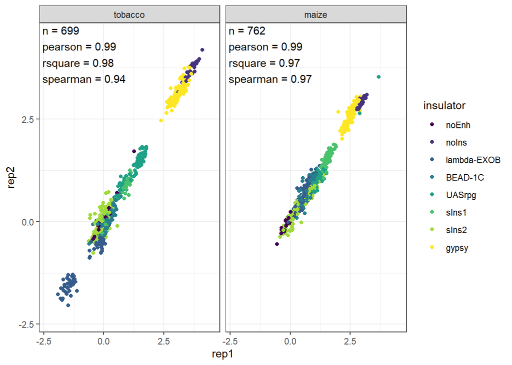

```r
data_FLins_norm |>
  select(rep, sys, barcode, insulator, orientation, enrichment) |>
  filter(rep %in% c(1, 2)) |>
  pivot_wider(
    names_from = rep,
    names_prefix = 'rep',
    values_from = enrichment
  ) |>
  drop_na(starts_with('rep')) |>
  pggfplot(
    filename = 'FLins_cor_rep',
    x = rep1,
    y = rep2,
    facet_col = sys,
    scales = 'square'
  ) |>
  pggf_scatter(color = insulator) |>
  pggf_stats(!! pggf_stat_fns$correlation)
```

Next, we create box plots for the enrichment of all barcodes linked to a given insulator.

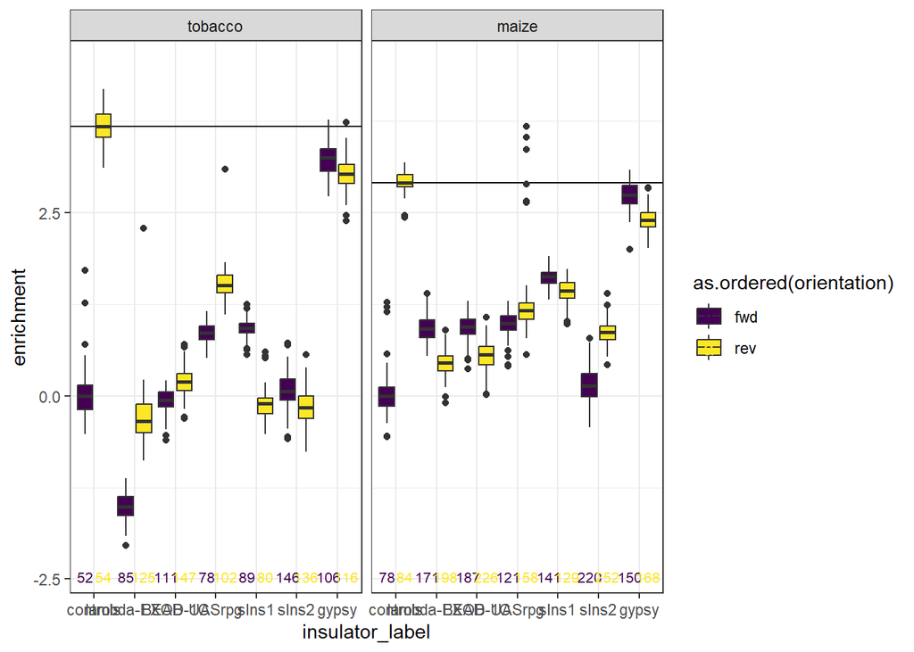

```r
data_FLins_norm |>
  mutate(
    sample = if_else(is.na(orientation), insulator, orientation),
    orientation = case_match(
      insulator,
      'noEnh' ~ 'fwd',
      'noIns' ~ 'rev',
      .default = orientation
    ),
    insulator_label = if_else(insulator %in% c('noEnh', 'noIns'), 'controls', insulator),
    insulator_label = ordered(insulator_label, levels = c('controls', insulator_order)),
    insulator_label = droplevels(insulator_label)
  ) |>
  pggfplot(
    filename = 'FLins_enrichment',
    x = insulator_label,
    y = enrichment,
    facet_col = sys
  ) |>
  pggf_hline(median(y[sample == 'noIns'])) |>
  pggf_boxplot(
    group = orientation,
    extra_cols = c(insulator, sample)
  )
```

## Insulator fragments

In the **iLib** library, We tested the activity of 170-bp fragments derived from the insulators in the **FLins** library. First we will check the replicate correlation to ensure that the data is reliable.

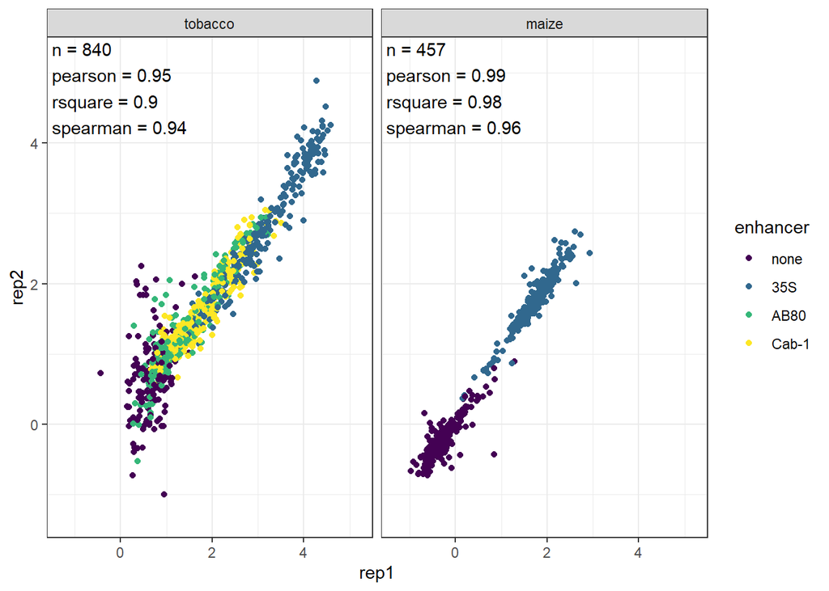

```r
data_iLib_norm |>
  select(rep, sys, enhancer, insulator, start, stop, orientation, enrichment) |>
  filter(rep %in% c(1, 2)) |>
  pivot_wider(
    names_from = rep,
    names_prefix = 'rep',
    values_from = enrichment
  ) |>
  drop_na(starts_with('rep')) |>
  pggfplot(
    filename = 'iLib_cor_rep',
    x = rep1,
    y = rep2,
    facet_col = sys,
    scales = 'square'
  ) |>
  pggf_scatter(color = enhancer) |>
  pggf_stats(!! pggf_stat_fns$correlation)
```

Then we create a violin plot to look at the distribution of enrichment values for all insulator fragment-containing constructs with a given enhancer.

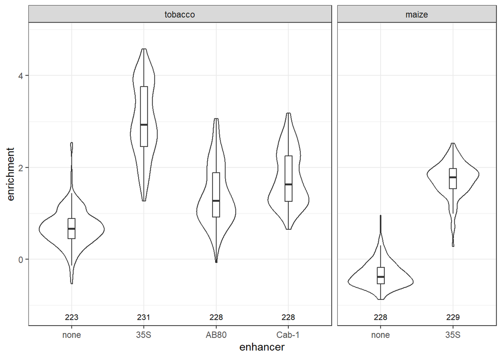

```r
data_iLib_mean |>
  group_by(sys, enhancer) |>
  mutate(
    noIns = enrichment[str_sub(insulator, 1, 2) == 'no']
  ) |>
  ungroup() |>
  filter(str_sub(insulator, 1, 2) != 'no') |>
  pggfplot(
    filename = 'iLib_enrichment',
    x = enhancer,
    y = enrichment,
    facet_col = sys,
    scales = 'free_x',
    space = 'free_x'
  ) |>
  pggf_violin(
    extra_cols = noIns
  )
```

The activity of the insulator fragments is dependent on the assay systems.

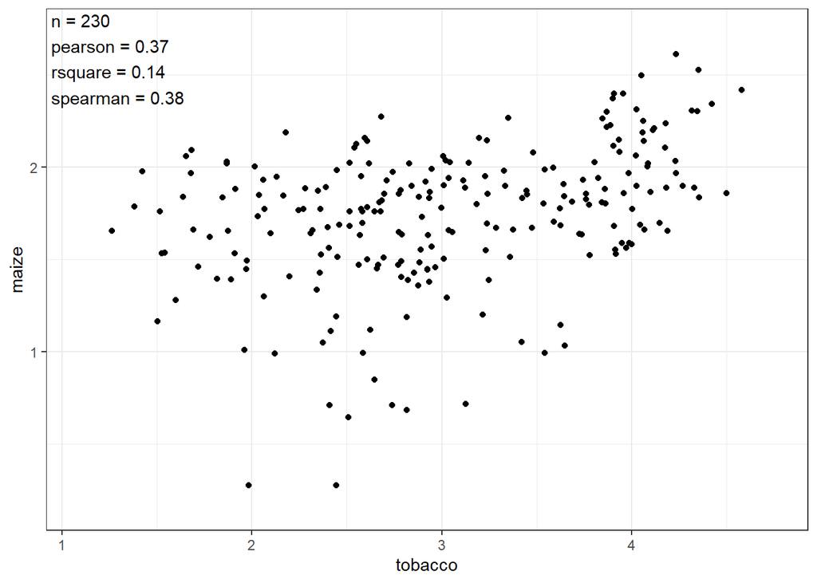

```r
data_iLib_mean |>
  select(sys, insulator, start, orientation, enhancer, enrichment) |>
  filter(enhancer == '35S') |>
  pivot_wider(
    names_from = sys,
    values_from = enrichment
  ) |>
  drop_na(tobacco, maize) |>
    pggfplot(
    filename = 'iLib_cor_species',
    x = tobacco,
    y = maize
  ) |>
  pggf_scatter() |>
  pggf_stats(!! pggf_stat_fns$correlation)
```

Plotting enrichment of insulator fragments by their position within the full-length insulator:

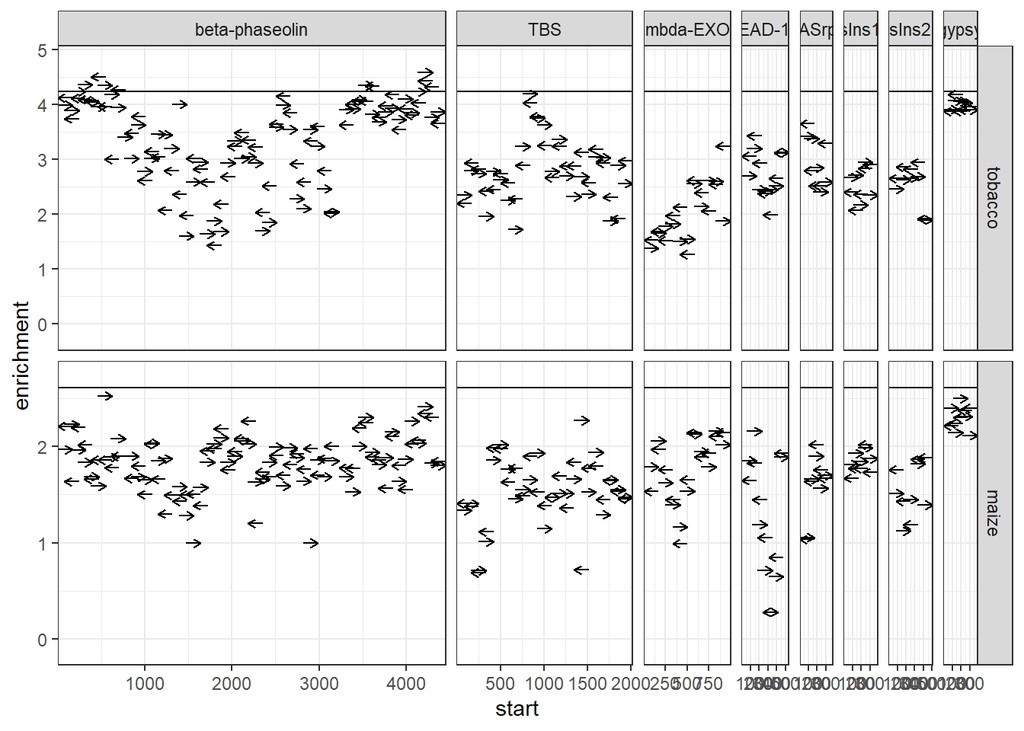

```r
data_iLib_mean |>
  filter(enhancer == '35S') |>
  mutate(
    start = if_else(orientation == 'fwd', start - 0.5, stop + 0.5),
    length = if_else(orientation == 'fwd', 170, -170)
  ) |>
  group_by(sys) |>
  mutate(
    noIns = enrichment[insulator == 'noIns']
  ) |>
  ungroup() |>
  filter(insulator != 'noIns') |>
  pggfplot(
    filename = 'iLib_position',
    x = start,
    y = enrichment,
    facet_col = insulator,
    facet_row = sys,
    scales = 'free',
    space = 'free_x',
    enlarge_x = 0,
    ymin = 0,
    ymax = data_iLib_mean |>
      filter(enhancer == '35S' & insulator == 'noIns') |>
      arrange(sys) |>
      pull(enrichment)
  ) |>
  pggf_hline(unique(noIns)) |>
  pggf_quiver(u = length)
```

GC content is a major contributor to insulator activity.

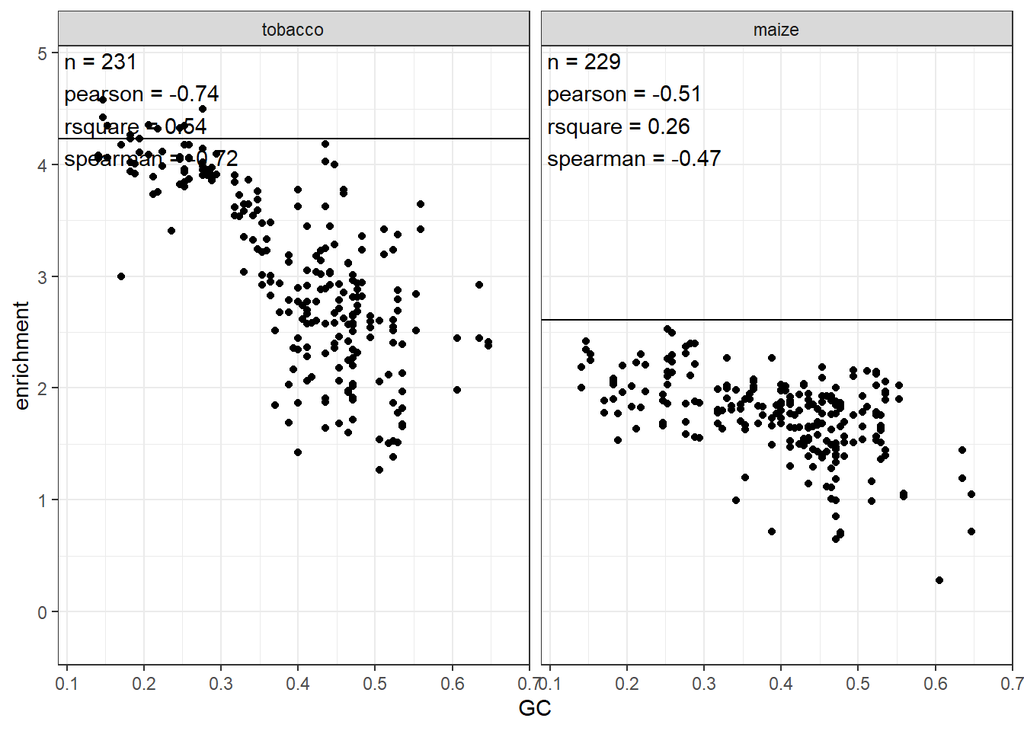

```r
data_iLib_mean |>
  filter(enhancer == '35S') |>
  group_by(sys) |>
  mutate(
    noIns = enrichment[insulator == 'noIns']
  ) |>
  ungroup() |>
  drop_na(GC, enrichment) |>
  pggfplot(
    filename = 'iLib_cor_GC',
    x = GC,
    y = enrichment,
    facet_col = sys,
    ymin = 0
  ) |>
  pggf_hline(unique(noIns)) |>
  pggf_scatter() |>
  pggf_stats(!! pggf_stat_fns$correlation)
```

The activity of the insulator fragments is largely independent of which enhancer sits upstream:

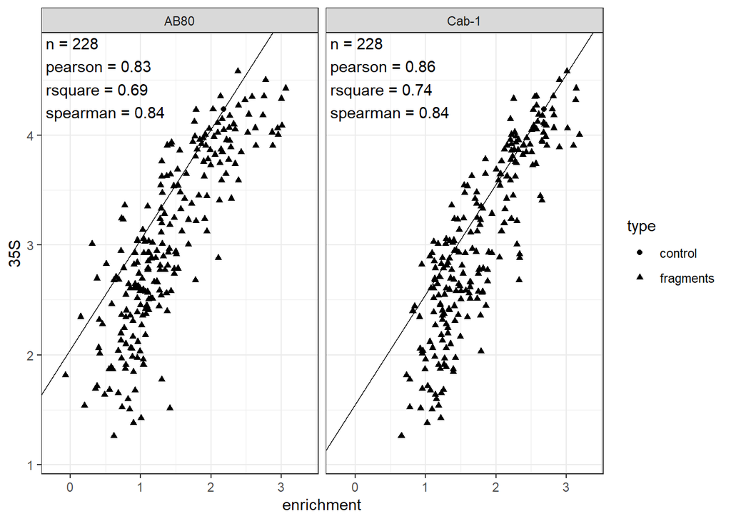

```r
data_iLib_mean |>
  select(sys, insulator, start, orientation, enhancer, enrichment) |>
  filter(enhancer != 'none' & sys == 'tobacco') |>
  pivot_wider(
    names_from = enhancer,
    values_from = enrichment
  ) |>
  pivot_longer(
    c(AB80, `Cab-1`),
    names_to = 'enh2',
    values_to = 'enrichment'
  ) |>
  drop_na(`35S`, enrichment) |>
  mutate(
    type = if_else(insulator == 'noIns', 'control', 'fragments'),
  ) |>
  pggfplot(
    filename = 'iLib_cor_enh',
    x = enrichment,
    y = `35S`,
    facet_col = enh2
  ) |>
  pggf_scatter(
    split = type
  ) |>
  pggf_stats(!! pggf_stat_fns$correlation) |>
  pggf_abline(intercept = y[type == 'control'] - x[type == 'control'])
```

Export data to a Supplementary Data file:

```r
DS_id <- 1

data_iLib_export <- data_iLib_mean |>
  select(sys, enhancer, insulator, start, stop, orientation, enrichment) |>
  pivot_wider(
    names_from = sys,
    values_from = enrichment
  ) |>
  arrange(enhancer, insulator, orientation, start) |>
  mutate(
    sequence = str_sub(FLins_seqs[as.character(insulator)], start, stop),
    sequence = if_else(
      orientation == 'rev',
      as.character(Biostrings::reverseComplement(Biostrings::DNAStringSet(replace_na(sequence, 'A')))),
      sequence
    ),
    sequence = replace_na(sequence, ''),
    insulator = str_replace(insulator, 'beta', 'β'),
    insulator = str_replace(insulator, 'lambda', 'λ')
  )

wb <- createWorkbook()

modifyBaseFont(wb, fontSize = 10, fontName = 'Arial')

addWorksheet(wb, sheetName = 'insulator fragments')

writeData(
  wb,
  sheet = 1,
  paste0('Supplementary Dataset S', DS_id, '. Enrichment of insulator fragment constructs.'),
  startCol = 1,
  startRow = 1
)

makeNameBold(wb, DS_id)
mergeCells(wb, sheet = 1, rows = 1, cols = seq_len(ncol(data_iLib_export)))

writeData(
  wb,
  sheet = 1,
  paste(
    "Known insulators were split into partially overlapping 170-bp fragments. The insulator fragments were cloned in the forward or reverse",
    "orientation between a 35S, AB80, or Cab-1 enhancer and a 35S minimal promoter driving the expression of a barcoded GFP reporter gene.",
    "Constructs without an enhancer (none) but with insulator fragments were also created. All insulator fragment constructs were pooled and",
    "subjected to Plant STARR-seq in N. benthamiana leaves (tobacco) and maize protoplasts (maize). Reporter mRNA enrichment was normalized to a",
    "control construct without an enhancer or insulator (noEnh; log2 set to 0)."
  ),
  startCol = 1,
  startRow = 2
)

addStyle(wb, sheet = 1, style = xlsx_wrap, rows = 2, cols = 1)
mergeCells(wb, sheet = 1, rows = 2, cols = seq_len(ncol(data_iLib_export)))
setRowHeights(wb, sheet = 1, rows = 2, heights = 12.75 * 6)

xlsx_header <- names(data_iLib_export)
enrichment_ids <- which(xlsx_header %in% c('tobacco', 'maize'))
xlsx_header[enrichment_ids] <- 'log2(enrichment)'

writeData(
  wb,
  sheet = 1,
  matrix(xlsx_header, nrow = 1),
  startCol = 1,
  startRow = 4,
  colNames = FALSE
)

addStyle(wb, sheet = 1, style = xlsx_boldwrap, cols = seq_along(xlsx_header), rows = 4)

writeData(
  wb,
  sheet = 1,
  data_iLib_export,
  startCol = 1,
  startRow = 5,
  headerStyle = xlsx_bold,
  keepNA = TRUE
)

mergeCells(wb, sheet = 1, rows = 4, cols = enrichment_ids)
addStyle(wb, sheet = 1, style = xlsx_center, rows = 4, cols = enrichment_ids, stack = TRUE)

for (i in seq_along(xlsx_header)[-enrichment_ids]) {
  mergeCells(wb, sheet = 1, rows = 4:5, cols = i)
}

addStyle(wb, sheet = 1, style = xlsx_2digit, cols = enrichment_ids, rows = 6:(nrow(data_iLib_export) + 6), gridExpand = TRUE)
addStyle(wb, sheet = 1, style = xlsx_seq_font, cols = which(xlsx_header == 'sequence'), rows = 6:(nrow(data_iLib_export) + 6))

freezePane(wb, sheet = 1, firstActiveRow = 6)

saveWorkbook(wb, paste0(supp_data_dir, 'SupplementaryDataset', DS_id, '.xlsx'), overwrite = TRUE)
```

## Insulators in stable lines

We tested some full-length insulators and insulator fragments in stable *Arabidopsis*, maize, and rice lines.

Let’s start with full-length insulators in *Arabidopsis*. They were tested with two different enhancers: the 35S and the *AB80* enhancer.

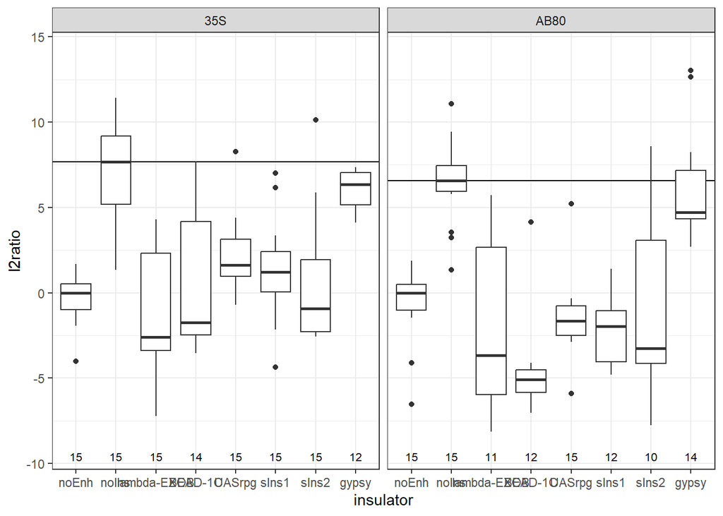

```r
data_DL |>
  filter(set %in% c('FLins', 'insAB')) |>
  pggfplot(
    filename = 'DL_FLins_Arabidopsis',
    x = insulator,
    y = l2ratio,
    facet_col = enhancer,
    scales = 'free_x',
    space = 'free_x'
  ) |>
  pggf_hline(median(y[xticklabels == 'noIns'])) |>
  pggf_boxplot()
```

These results closely match our Plant STARR-seq measurements in tobacco.

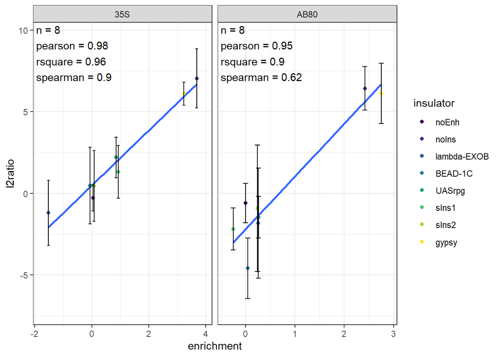

```r
data_DL_FLins_tobacco_summary <- data_DL |>
  filter(set %in% c('FLins', 'insAB')) |>
  group_by(enhancer, insulator) |>
  summarise(
    CI = 0.5 * diff(t.test(l2ratio)$conf.int),
    l2ratio = mean(l2ratio),
    .groups = 'drop'
  )

data_FLins_norm |>
  filter(sys == 'tobacco' & (insulator %in% c('noEnh', 'noIns') | orientation == 'fwd')) |>
  mutate(
    enhancer = if_else(insulator == 'noEnh', '35S', enhancer)
  ) |>
  bind_rows(
    data_ExI_norm |>
      mutate(
        enhancer = if_else(insulator == 'noEnh', 'AB80', enhancer)
      ) |>
      filter(sys == 'tobacco' & enhancer == 'AB80' & type %in% c('control', 'FL'))
  ) |>
  group_by(enhancer, insulator) |>
  summarise(
    enrichment = mean(enrichment),
    .groups = 'drop'
  ) |>
  inner_join(
    data_DL_FLins_tobacco_summary,
    by = c('enhancer', 'insulator')
  ) |>
  pggfplot(
    filename = 'DL_cor_Flins_Arabidopsis',
    x = enrichment,
    y = l2ratio,
    facet_col = enhancer,
    scales = 'free_x'
  ) |>
  pggf_trendline() |>
  pggf_scatter(
    color = insulator,
    y_error = CI
  ) |>
  pggf_stats(!! pggf_stat_fns$correlation)
```

We also tested the novel synthetic insulators in stable rice lines.

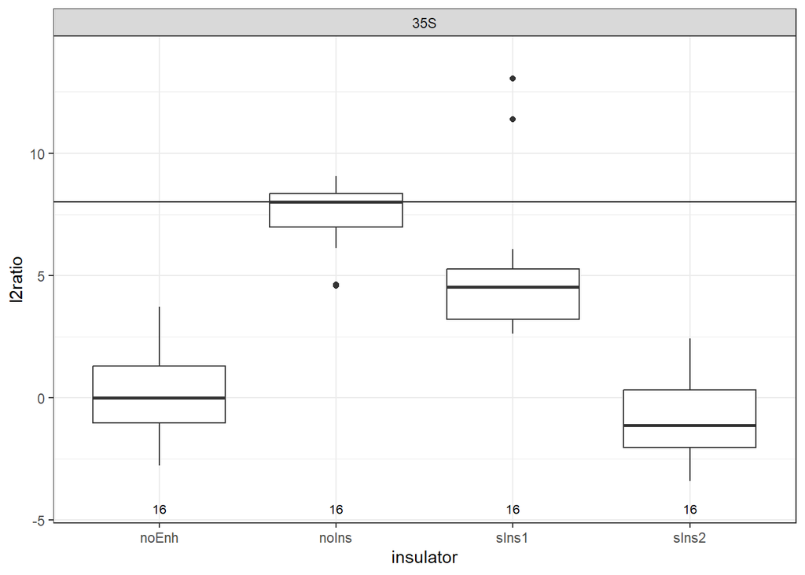

```r
data_DL |>
  filter(set == 'rice') |>
  pggfplot(
    filename = 'DL_FLins_rice',
    x = insulator,
    y = l2ratio,
    facet_col = enhancer,
    scales = 'free_x',
    space = 'free_x'
  ) |>
  pggf_hline(median(y[xticklabels == 'noIns'])) |>
  pggf_boxplot()
```

These results closely match our Plant STARR-seq measurements in maize.

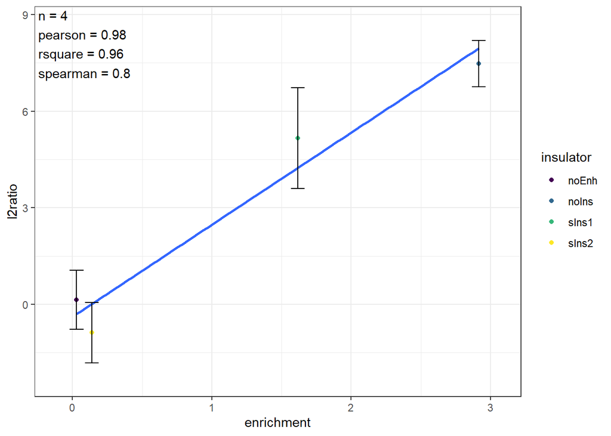

```r
data_DL_FLins_tobacco_summary <- data_DL |>
  filter(set == 'rice') |>
  group_by(insulator) |>
  summarise(
    CI = 0.5 * diff(t.test(l2ratio)$conf.int),
    l2ratio = mean(l2ratio),
    .groups = 'drop'
  )

data_FLins_norm |>
  filter(sys == 'maize' & (insulator %in% c('noEnh', 'noIns') | orientation == 'fwd')) |>
  group_by(insulator) |>
  summarise(
    enrichment = mean(enrichment),
    .groups = 'drop'
  ) |>
  inner_join(
    data_DL_FLins_tobacco_summary,
    by = 'insulator'
  ) |>
  pggfplot(
    filename = 'DL_cor_Flins_rice',
    x = enrichment,
    y = l2ratio
  ) |>
  pggf_trendline() |>
  pggf_scatter(
    color = insulator,
    y_error = CI
  ) |>
  pggf_stats(!! pggf_stat_fns$correlation)
```

Insulator fragments were also tested in stable *Arabidopsis* lines.

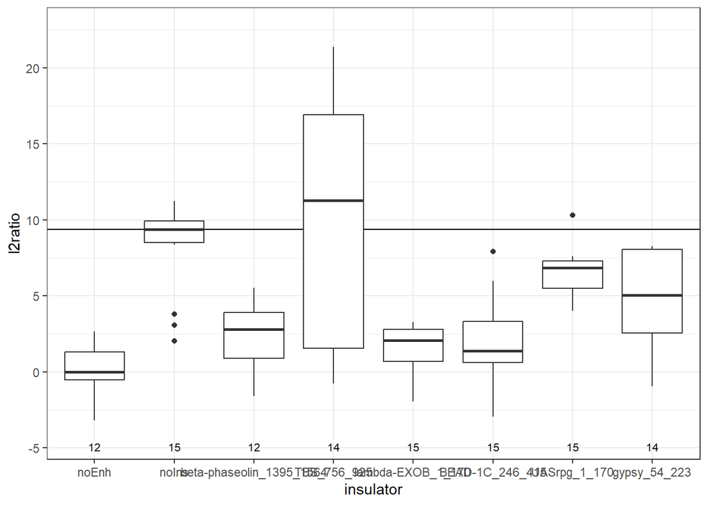

```r
data_DL |>
  filter(set == 'frag') |>
  mutate(
    order = as.numeric(insulator)
  ) |>
  unite(
    'insulator',
    insulator,
    start,
    stop,
    na.rm = TRUE
  ) |>
  mutate(
    insulator = ordered(insulator, levels = unique(insulator[order(order)]))
  ) |>
  pggfplot(
    filename = 'DL_frags_Arabidopsis',
    x = insulator,
    y = l2ratio,
    scales = 'free_x',
    space = 'free_x'
  ) |>
  pggf_hline(median(y[xticklabels == 'noIns'])) |>
  pggf_boxplot()
```

Again, we see a good correlation between results from Plant STARR-seq and stable lines.

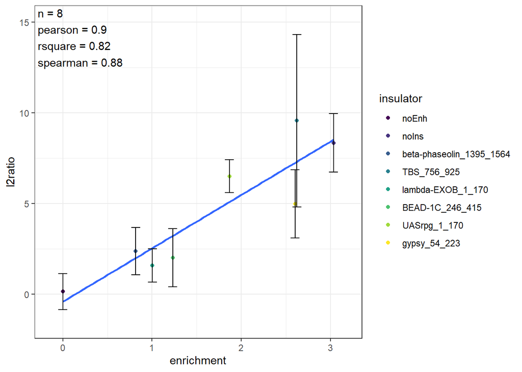

```r
data_DL_frags_summary <- data_DL |>
  filter(set == 'frag') |>
  group_by(insulator, start, stop) |>
  summarise(
    CI = 0.5 * diff(t.test(l2ratio)$conf.int),
    l2ratio = mean(l2ratio),
    .groups = 'drop'
  )

data_iLib_mean |>
  filter(sys == 'tobacco' & (insulator %in% c('noEnh', 'noIns') | orientation == 'fwd')) |>
  group_by(insulator, start) |>
  summarise(
    enrichment = mean(enrichment),
    .groups = 'drop'
  ) |>
  inner_join(
    data_DL_frags_summary,
    by = c('insulator', 'start'),
  ) |>
  mutate(
    order = as.numeric(insulator)
  ) |>
  unite(
    'insulator',
    insulator,
    start,
    stop,
    na.rm = TRUE
  ) |>
  mutate(
    insulator = ordered(insulator, levels = unique(insulator[order(order)]))
  ) |>
  pggfplot(
    filename = 'DL_cor_frags_Arabidopsis',
    x = enrichment,
    y = l2ratio
  ) |>
  pggf_trendline() |>
  pggf_scatter(
    color = insulator,
    y_error = CI
  ) |>
  pggf_stats(!! pggf_stat_fns$correlation)
```

Finally, insulator fragments were also tested in stable maize lines using ELISA as a readout.

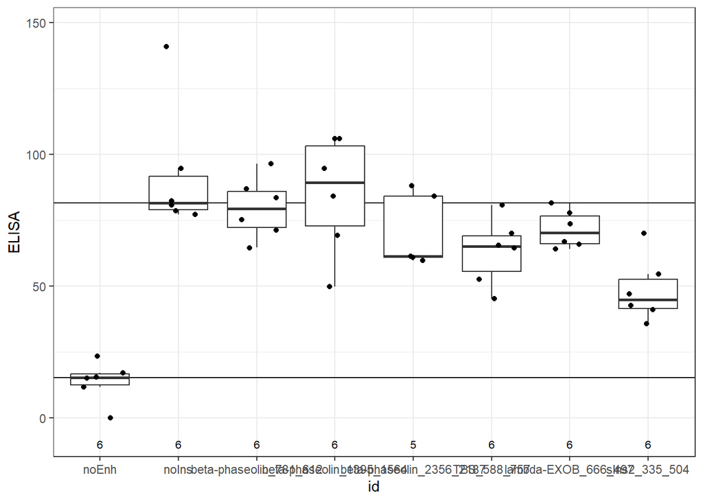

```r
data_ELISA <- read_tsv('../../data/Corteva/insulator_fragments_maize.tsv', show_col_types = FALSE) |>
  separate_wider_delim(
    id,
    delim = '_',
    names = c('insulator', 'start', 'end', 'orientation'),
    too_few = 'align_start'
  ) |>
  mutate(
    tmp = start,
    start = if_else(orientation == 'rev', end, start),
    end = if_else(orientation == 'rev', tmp, end)
  ) |>
  unite(
    'id',
    insulator,
    start,
    end,
    na.rm = TRUE,
    remove = FALSE
  ) |>
  select(-tmp)

insFrag_order <- data_ELISA |>
  distinct(id, insulator, start) |>
  mutate(
    insulator = ordered(insulator, levels = insulator_order),
    start = as.numeric(start)
  ) |>
  arrange(insulator, start) |>
  pull(id)

# plot for R1 leaves
data_ELISA |>
  mutate(
    id = ordered(id, levels = insFrag_order)
  ) |>
  rename('ELISA' = R1_leaf) |>
  drop_na(ELISA) |>
  pggfplot(
    filename = 'ELISA_R1_leaf',
    x = id,
    y = ELISA
  ) |>
  pggf_hline(
    list(c('noIns' = median(y[xticklabels == 'noIns']), 'noEnh' = median(y[xticklabels == 'noEnh'])))
  ) |>
  pggf_boxplot()
```

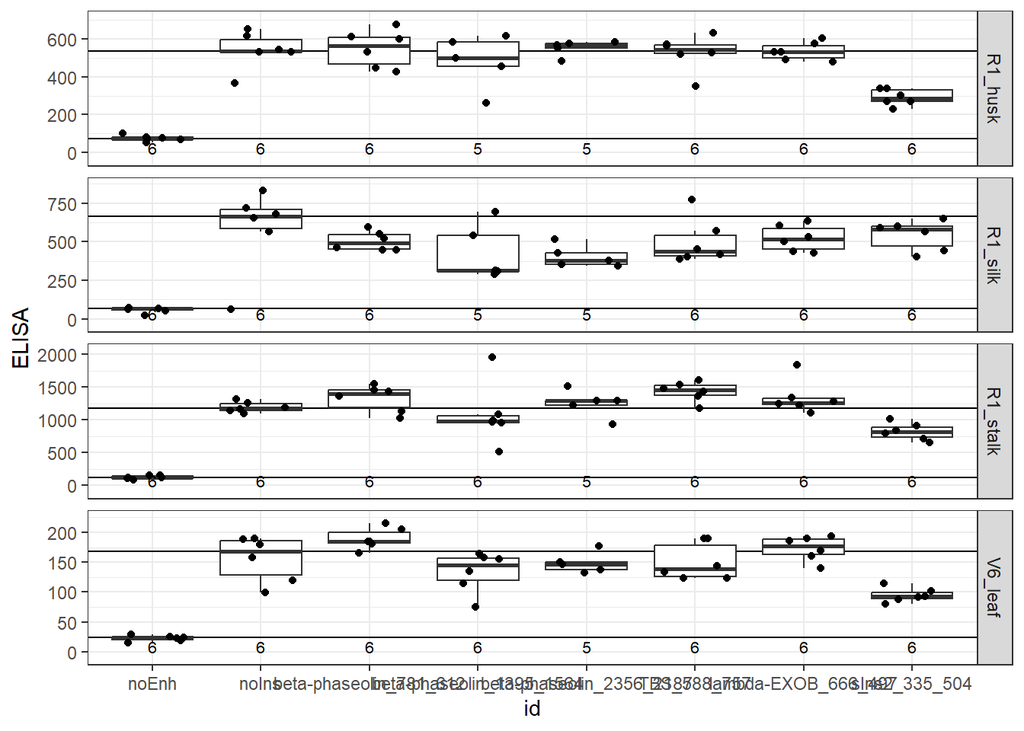

```r
# plot for other tissues/developmental stages
data_ELISA |>
  mutate(
    id = ordered(id, levels = insFrag_order)
  ) |>
  pivot_longer(
    starts_with(c('V6', 'R1')),
    names_to = 'sample',
    values_to = 'ELISA'
  ) |>
  drop_na(ELISA) |>
  filter(sample != 'R1_leaf') |>
  pggfplot(
    filename = 'ELISA_samples',
    x = id,
    y = ELISA,
    facet_row = sample,
    scales = 'free_y',
    ymin = 0
  ) |>
  pggf_hline(
    list(c('noIns' = median(y[xticklabels == 'noIns']), 'noEnh' = median(y[xticklabels == 'noEnh'])))
  ) |>
  pggf_boxplot()
```

The ELISA results resemble our Plant STARR-seq data in maize.

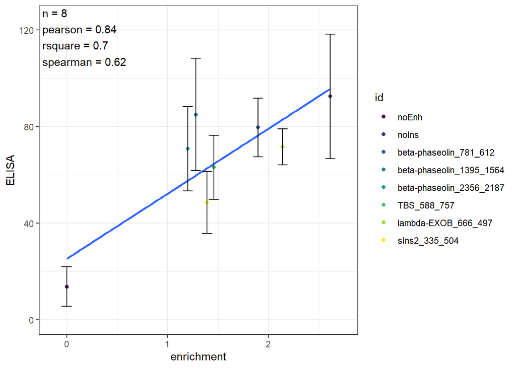

```r
data_ELISA_summary <- data_ELISA |>
  pivot_longer(
    starts_with(c('V6', 'R1')),
    names_to = 'sample',
    values_to = 'ELISA'
  ) |>
  drop_na(ELISA) |>
  group_by(id, sample) |>
  summarise(
    CI = 0.5 * diff(t.test(ELISA)$conf.int),
    ELISA = mean(ELISA),
    .groups = 'drop'
  )

data_ELISA_summary <- data_iLib_mean |>
  filter(sys == 'maize' & (enhancer == '35S' | insulator == 'noEnh')) |>
  mutate(
    tmp = start,
    start = if_else(orientation == 'rev', stop, start),
    stop = if_else(orientation == 'rev', tmp, stop)
  ) |>
  unite(
    'id',
    insulator,
    start,
    stop,
    na.rm = TRUE,
    remove = FALSE
  ) |>
  select(-tmp) |>
  inner_join(
    data_ELISA_summary,
    by = 'id',
  ) |>
  mutate(
    id = ordered(id, levels = insFrag_order)
  )

# plot for R1 leaves
data_ELISA_summary |>
  filter(sample == 'R1_leaf') |>
  pggfplot(
    filename = 'ELISA_cor_R1_leaf',
    x = enrichment,
    y = ELISA
  ) |>
  pggf_trendline() |>
  pggf_scatter(
    color = id,
    y_error = CI
  ) |>
  pggf_stats(!! pggf_stat_fns$correlation)
```

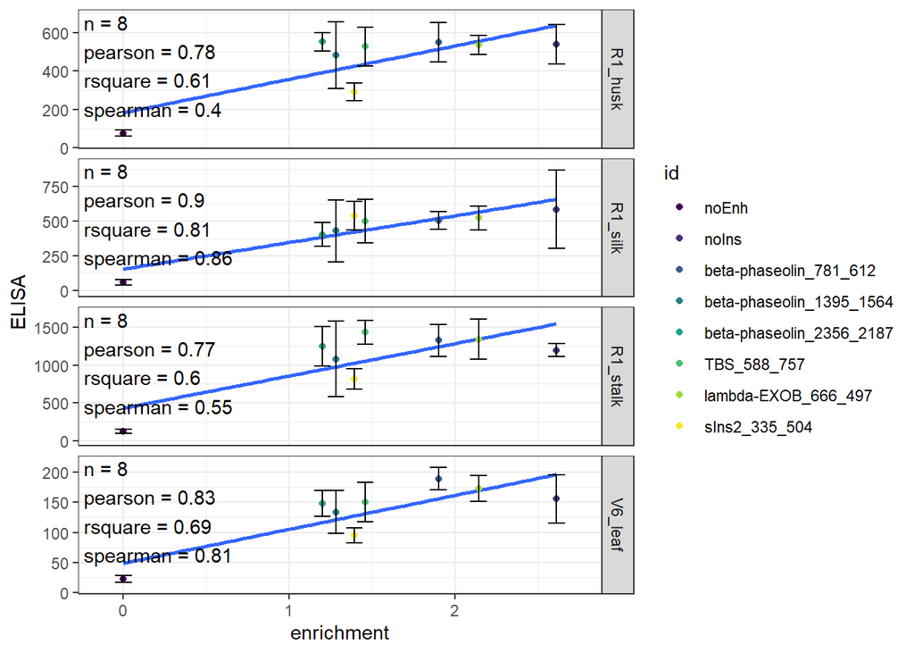

```r
# plot for other tissues/developmental stages
data_ELISA_summary |>
  filter(sample != 'R1_leaf') |>
  pggfplot(
    filename = 'ELISA_cor_samples',
    x = enrichment,
    y = ELISA,
    facet_row = sample,
    scales = 'free_y'
  ) |>
  pggf_trendline() |>
  pggf_scatter(
    color = id,
    y_error = CI
  ) |>
  pggf_stats(!! pggf_stat_fns$correlation)
```

We tested the activity of the insulator fragments in several maize tissues and observed strong correlation between the results.

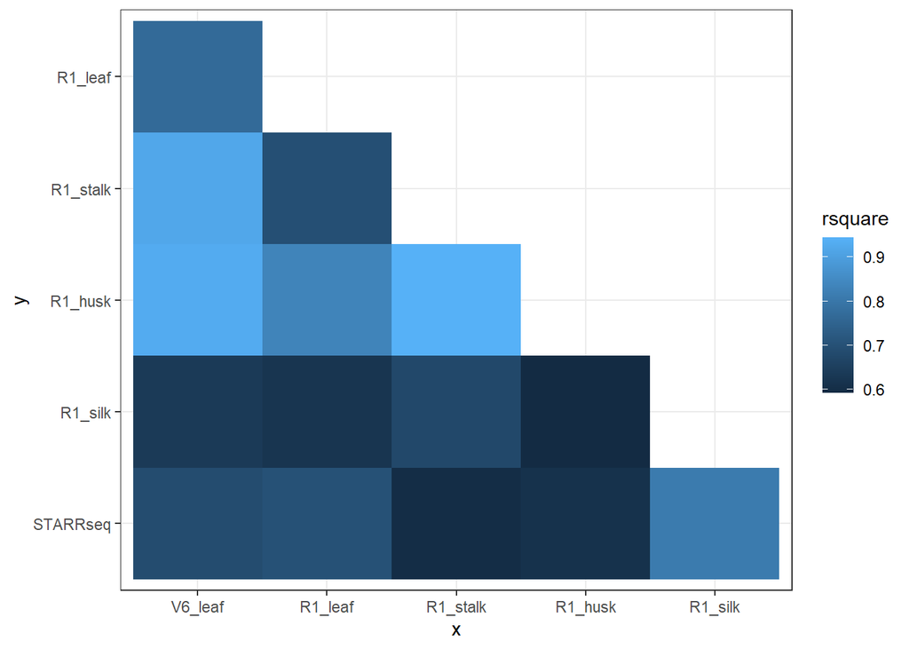

```r
sample_order <- c('V6_leaf', 'R1_leaf', 'R1_stalk', 'R1_husk', 'R1_silk', 'STARRseq')

ELISA_cor <- data_ELISA_summary |>
  select(id, sample, 'STARRseq' = enrichment, ELISA) |>
  pivot_wider(names_from = sample, values_from = ELISA) |>
  select(all_of(sample_order)) |>
  cor(use = 'complete.obs')

ELISA_cor[! lower.tri(ELISA_cor)] <- NA

ELISA_cor |>
  as_tibble(rownames = 'y') |>
  pivot_longer(
    -y,
    names_to = 'x',
    values_to = 'cor'
  ) |>
  mutate(
    across(c(x, y), ~ ordered(.x, levels = sample_order)),
    rsquare = cor^2
  ) |>
  drop_na(rsquare) |>
  pggfplot(
    filename = 'ELISA_tissues',
    x = x,
    y = y
  ) |>
  pggf_heatmap(
    color = rsquare
  )
```

## Insulator fragment combinations

Insulator fragments block the 35S enhancer only partially. We were wondering if stacking two or three insulator fragments can yield very strong insulators. To this end, we created the **iFC** library in which we tested the enhancer-blocking activity of 32 insulator fragments alone (single insulator constructs) or in all possible pairwise combinations (double insulator constructs). Finally, we also created versions with three insulator fragments (triple insulator constructs) by cloning one of five strong (in tobacco) insulator fragments upstream of the two insulator fragments in the double insulator constructs. Replicate correlations were high for experiments with this library.

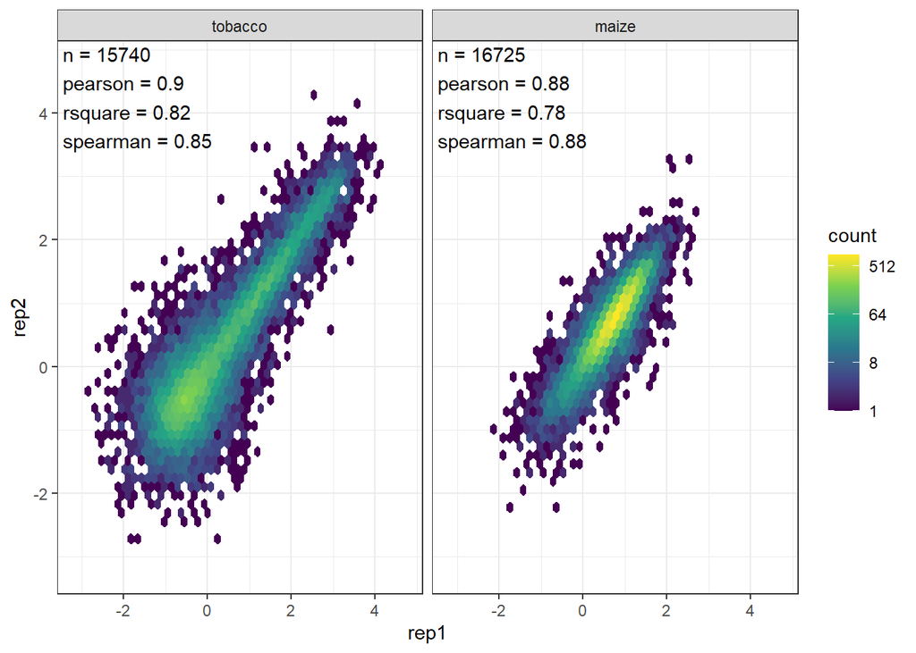

```r
data_iFC_norm |>
  select(rep, sys, starts_with(c('id_', 'orientation_')), enrichment) |>
  pivot_wider(
    names_from = rep,
    names_prefix = 'rep',
    values_from = enrichment
  ) |>
  drop_na(starts_with('rep')) |>
  pggfplot(
    filename = 'iFC_cor_rep',
    x = rep1,
    y = rep2,
    facet_col = sys,
    scales = 'square'
  ) |>
  pggf_hexbin() |>
  pggf_stats(!! pggf_stat_fns$correlation)
```

Stacking two or more insulator fragments increases the enhancer-blocking effect.

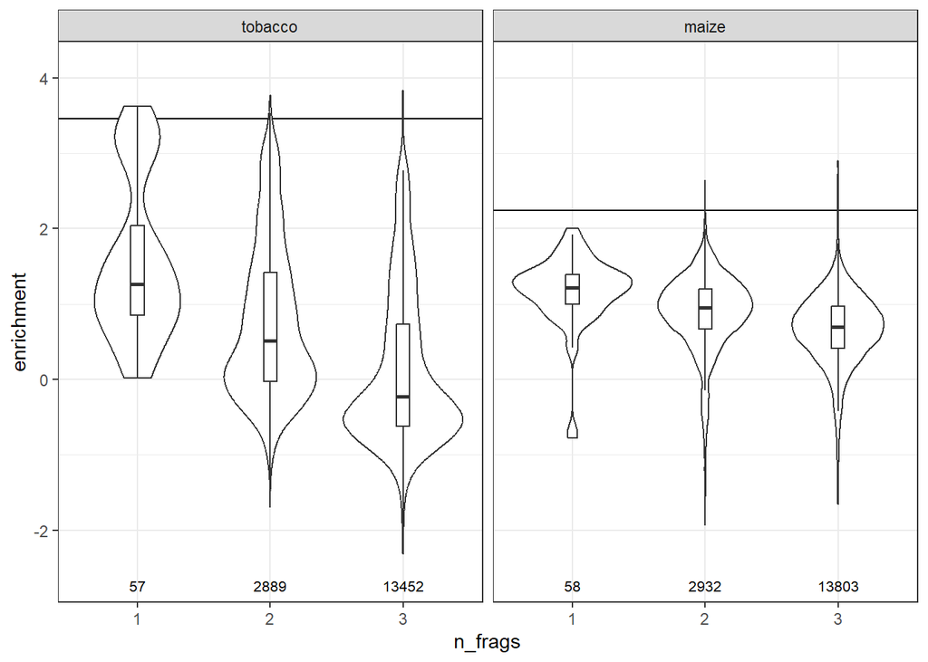

```r
data_iFC_mean |>
  group_by(sys) |>
  mutate(
    n_frags = case_match(
      type,
      'single' ~ '1',
      'double' ~ '2',
      'triple' ~ '3'
    ),
    noIns = enrichment[id_1 == 'noIns']
  ) |>
  ungroup() |>
  filter(type != 'control') |>
  pggfplot(
    filename = 'iFC_enrichment',
    x = n_frags,
    y = enrichment,
    facet_col = sys
  ) |>
  pggf_hline(unique(noIns)) |>
  pggf_violin()
```

To predict the enhancer-blocking activity of insulator fragment combinations, we can build a simple linear model using the activity of the individual fragments (as measured in the iLib library) and there position in the stack as inputs.

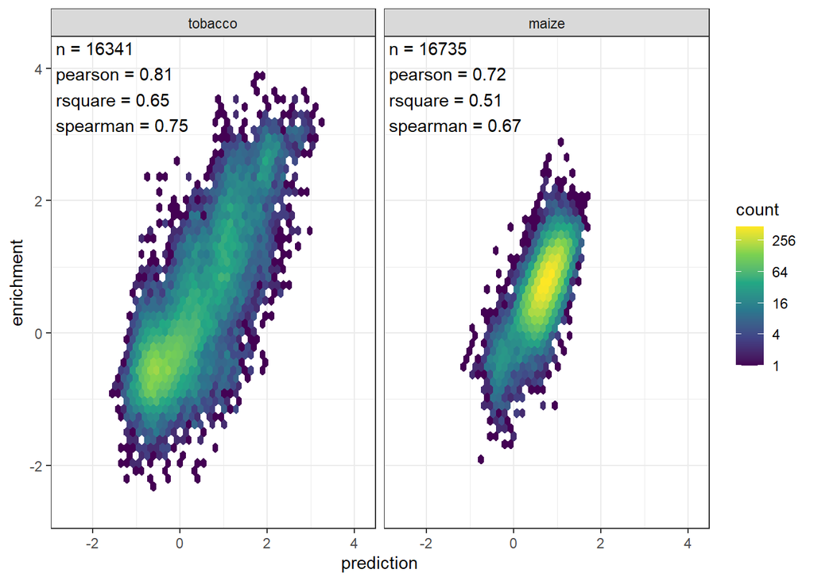

```r
individual_frags <- data_iLib_mean |>
  filter(enhancer == '35S') |>
  group_by(sys) |>
  mutate(
    activity = enrichment[insulator == 'noIns'] - enrichment
  ) |>
  ungroup() |>
  filter(! grepl('no', insulator, fixed = TRUE)) |>
  unite(
    'fragment',
    insulator,
    start,
    orientation,
    sys
  ) |>
  select(fragment, activity) |>
  deframe()


iFC_models <- data_iFC_mean |>
  unite(
    'fragment_1',
    id_1,
    orientation_1,
    sys,
    na.rm = TRUE,
    remove = FALSE
  ) |>
  unite(
    'fragment_2',
    id_2,
    orientation_2,
    sys,
    na.rm = TRUE,
    remove = FALSE
  ) |>
  unite(
    'fragment_3',
    id_3,
    orientation_3,
    sys,
    na.rm = TRUE,
    remove = FALSE
  ) |>
  group_by(sys) |>
  mutate(
    noIns = enrichment[id_1 == 'noIns'],
    activity = noIns - enrichment,
    across(starts_with('fragment_'), ~ individual_frags[.x]),
    across(starts_with('fragment_'), ~ replace_na(.x, 0))
  ) |>
  ungroup() |>
  filter(! is.na(id_2)) |>
  nest_by(sys, noIns) |>
  reframe(
    model = list(lm(activity ~ fragment_1 + fragment_2 + fragment_3, data = data)),
    enrichment = data$enrichment,
    prediction = noIns - predict(model, data = data),
    coefficients = list(coef(model))
  ) |>
  select(-model, -noIns)

iFC_models |>
  pggfplot(
    filename = 'iFC_cor_prediction',
    x = prediction,
    y = enrichment,
    facet_col = sys,
    scales = 'square'
  ) |>
  pggf_hexbin() |>
  pggf_stats(!! pggf_stat_fns$correlation)
```

The coefficients of the model reveal that the fragment closest to the minimal promoter (and furthest away from the enhancer) has the strongest impact on overall enhancer-blocking activity.

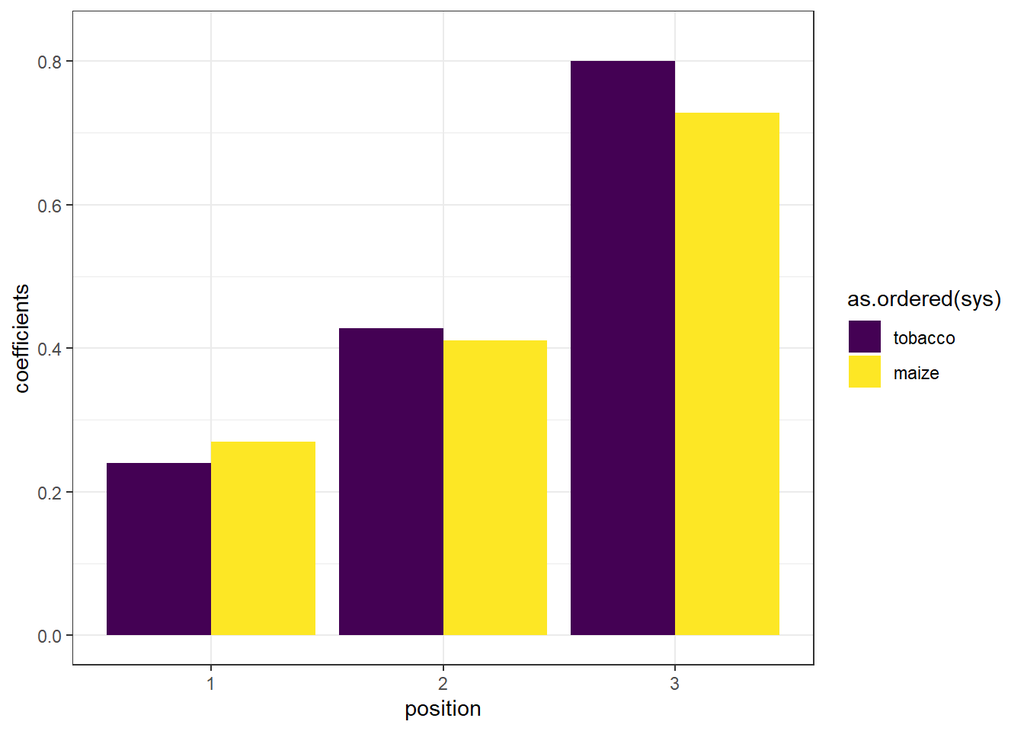

```r
iFC_models |>
  distinct(sys, coefficients) |>
  unnest_longer(coefficients) |>
  filter(coefficients_id != '(Intercept)') |>
  mutate(
    position = case_match(
      coefficients_id,
      'fragment_1' ~ '3',
      'fragment_2' ~ '2',
      'fragment_3' ~ '1'
    )
  ) |>
  pggfplot(
    filename = 'iFC_model_coef',
    x = position,
    y = coefficients
  ) |>
  pggf_bar(
    group = sys
  )
```

Export data to a Supplementary Data file:

```r
DS_id <- 2

expand_id <- function(id) {
  df <- tibble(
    insulator = str_replace(id, '_.*', ''),
    start = as.numeric(str_extract(id, '(?<=_)[0-9]+')),
    stop = start + 169,
    orientation = str_replace(id, '.*_', ''),
    sequence = str_sub(FLins_seqs[insulator], start, stop),
  ) |>
    mutate(
      sequence = if_else(
        orientation == 'rev',
        as.character(Biostrings::reverseComplement(Biostrings::DNAStringSet(replace_na(sequence, 'A')))),
        sequence
      )
    ) |>
    unite(
      'fragment',
      insulator,
      start,
      stop,
      orientation,
      na.rm = TRUE
    )

  return(df)
}

data_iFC_export <- data_iFC_mean |>
  unite(
    'id_1',
    id_1,
    orientation_1,
    na.rm = TRUE
  ) |>
  unite(
    'id_2',
    id_2,
    orientation_2,
    na.rm = TRUE
  ) |>
  unite(
    'id_3',
    id_3,
    orientation_3,
    na.rm = TRUE
  ) |>
  mutate(
    n_frags = case_match(
      type,
      'single' ~ 1,
      'double' ~ 2,
      'triple' ~ 3,
      .default = 0
    )
  ) |>
  mutate(
    across(starts_with('id'), ~ if_else(.x == '', NA, .x)),
    across(starts_with('id'), expand_id, .unpack = '{inner}_{str_replace(outer, "id_", "")}')
  ) |>
  mutate(
    sequence_3 = if_else(is.na(sequence_3), '', paste0(sequence_3, 'actc')),
    sequence_2 = if_else(is.na(sequence_2), '', paste0(sequence_2, 'ctgt')),
    sequence_1 = replace_na(sequence_1, ''),
    sequence = paste0(sequence_3, sequence_2, sequence_1),
  ) |>
  select(sys, n_frags, starts_with('fragment'), enrichment, sequence) |>
  pivot_wider(
    names_from = sys,
    values_from = enrichment
  ) |>
  arrange(-n_frags, fragment_3, fragment_2, fragment_1) |>
  select('number of fragments' = n_frags, 'fragment 3' = fragment_3, 'fragment 2' = fragment_2, 'fragment 1' = fragment_1, tobacco, maize, sequence) |>
  mutate(
    across(starts_with('fragment'), ~ str_replace(.x, 'beta', 'β')),
    across(starts_with('fragment'), ~ str_replace(.x, 'lambda', 'λ')),
  )

wb <- createWorkbook()

modifyBaseFont(wb, fontSize = 10, fontName = 'Arial')

addWorksheet(wb, sheetName = 'insulator fragment combinations')

writeData(
  wb,
  sheet = 1,
  paste0('Supplementary Dataset S', DS_id,'. Enrichment of insulator fragment combination constructs.'),
  startCol = 1,
  startRow = 1
)

makeNameBold(wb, DS_id)
mergeCells(wb, sheet = 1, rows = 1, cols = seq_len(ncol(data_iFC_export)))

writeData(
  wb,
  sheet = 1,
  paste(
    "One, two, or three 170-bp fragments of known insulators were cloned between a 35S enhancer and a 35S minimal promoter driving the",
    "expression of a barcoded GFP reporter gene. All insulator constructs were pooled and subjected to Plant STARR-seq in N. benthamiana leaves",
    "(tobacco) and maize protoplasts (maize). Reporter mRNA enrichment was normalized to a control construct without an enhancer or insulator",
    "(log2 set to 0)."
  ),
  startCol = 1,
  startRow = 2
)

addStyle(wb, sheet = 1, style = xlsx_wrap, rows = 2, cols = 1)
mergeCells(wb, sheet = 1, rows = 2, cols = seq_len(ncol(data_iFC_export)))
setRowHeights(wb, sheet = 1, rows = 2, heights = 12.75 * 4)

xlsx_header <- names(data_iFC_export)
enrichment_ids <- which(xlsx_header %in% c('tobacco', 'maize'))
xlsx_header[enrichment_ids] <- 'log2(enrichment)'

writeData(
  wb,
  sheet = 1,
  matrix(xlsx_header, nrow = 1),
  startCol = 1,
  startRow = 4,
  colNames = FALSE
)

addStyle(wb, sheet = 1, style = xlsx_boldwrap, cols = seq_along(xlsx_header), rows = 4)

writeData(
  wb,
  sheet = 1,
  data_iFC_export,
  startCol = 1,
  startRow = 5,
  headerStyle = xlsx_bold,
  keepNA = TRUE
)

mergeCells(wb, sheet = 1, rows = 4, cols = enrichment_ids)
addStyle(wb, sheet = 1, style = xlsx_center, rows = 4, cols = enrichment_ids, stack = TRUE)

for (i in seq_along(xlsx_header)[-enrichment_ids]) {
  mergeCells(wb, sheet = 1, rows = 4:5, cols = i)
}

addStyle(wb, sheet = 1, style = xlsx_2digit, cols = enrichment_ids, rows = 6:(nrow(data_iFC_export) + 6), gridExpand = TRUE)
addStyle(wb, sheet = 1, style = xlsx_seq_font, cols = which(xlsx_header == 'sequence'), rows = 6:(nrow(data_iFC_export) + 6))

setColWidths(wb, sheet = 1, cols = grep('fragment ', xlsx_header), widths = 24)

freezePane(wb, sheet = 1, firstActiveRow = 6)

saveWorkbook(wb, paste0(supp_data_dir, 'SupplementaryDataset', DS_id, '.xlsx'), overwrite = TRUE)
```

### Insulator fragment combinations in stable maize lines

Similar to the single insulator fragments, we also tested several insulator fragment combinations in stable maize lines.

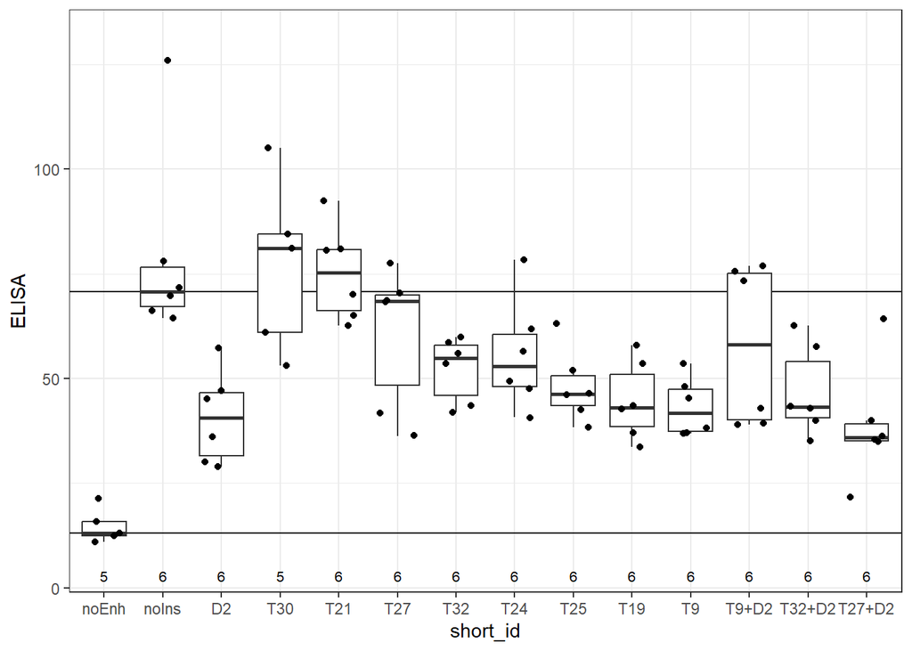

```r
data_ELISA_iFC <- read_tsv('../../data/Corteva/stacked_insulators_maize.tsv', show_col_types = FALSE) |>
  separate_wider_delim(
    id,
    delim = '+',
    names_sep = '_',
    too_few = 'align_end'
  ) |>
  mutate(
    across(
      starts_with('id_'),
      ~ if_else(
        str_detect(.x, '_rev'),
        str_match_all(.x, '(.*)_(.*)_(.*)_(.*)') |> sapply(function(x) paste(x[2], x[4], x[3], x[5], sep = '_')),
        .x
      )
    )
  ) |>
  rename_with(~ paste0('id_', 6 - as.numeric(str_sub(.x, 4))), starts_with('id_')) |>
  unite(
    'id',
    starts_with('id_'),
    sep = '+',
    na.rm = TRUE,
    remove = FALSE
  ) |>
  mutate(
    n_frags = case_when(
      ! is.na(id_5) ~ 5,
      ! is.na(id_3) ~ 3,
      ! is.na(id_2) ~ 2
    )
  ) |>
  filter(short_id != 'T17') # only three independent lines for T17

stackedIns_order <- c(
  'noEnh',
  'noIns',
  data_ELISA_iFC |>
    filter(! id %in% c('noEnh', 'noIns')) |>
    group_by(short_id, n_frags) |>
    summarise(
      rank = median(R1_leaf),
      .groups = 'drop'
    ) |>
    arrange(n_frags, -rank) |>
    pull(short_id)
)

# plot for R1 leaves
data_ELISA_iFC |>
  mutate(
    short_id = ordered(short_id, levels = stackedIns_order)
  ) |>
  rename('ELISA' = R1_leaf) |>
  drop_na(ELISA) |>
  pggfplot(
    filename = 'ELISA_stacked_R1_leaf',
    x = short_id,
    y = ELISA
  ) |>
  pggf_hline(
    list(c('noIns' = median(y[xticklabels == 'noIns']), 'noEnh' = median(y[xticklabels == 'noEnh'])))
  ) |>
  pggf_boxplot()
```

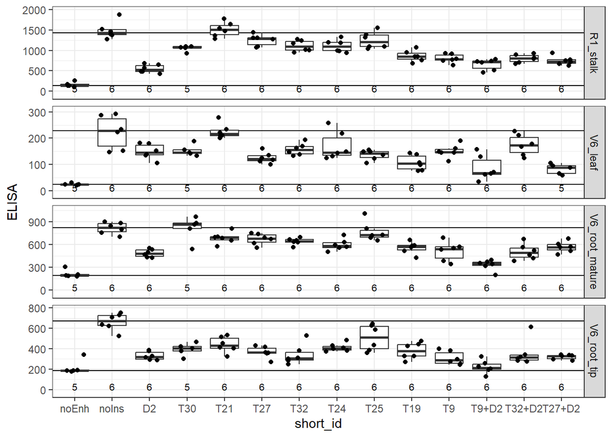

```r
# plot for other tissues/developmental stages
data_ELISA_iFC |>
  mutate(
    short_id = ordered(short_id, levels = stackedIns_order)
  ) |>
  pivot_longer(
    starts_with(c('V6', 'R1')),
    names_to = 'sample',
    values_to = 'ELISA'
  ) |>
  drop_na(ELISA) |>
  filter(sample != 'R1_leaf') |>
  pggfplot(
    filename = 'ELISA_stacked_samples',
    x = short_id,
    y = ELISA,
    facet_row = sample,
    scales = 'free_y',
    ymin = 0
  ) |>
  pggf_hline(
    list(c('noIns' = median(y[xticklabels == 'noIns']), 'noEnh' = median(y[xticklabels == 'noEnh'])))
  ) |>
  pggf_boxplot()
```

We can compare these results to the Plant STARR-seq data:

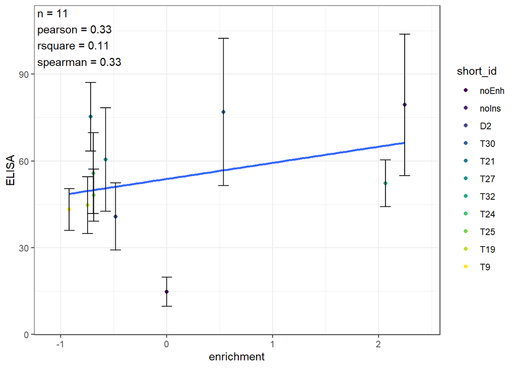

```r
data_ELISA_iFC_summary <- data_ELISA_iFC |>
  filter(is.na(id_4)) |>
  select(-c(id_4, id_5)) |>
  pivot_longer(
    starts_with(c('V6', 'R1')),
    names_to = 'sample',
    values_to = 'ELISA'
  ) |>
  drop_na(ELISA) |>
  group_by(pick(contains('id')), sample) |>
  summarise(
    CI = 0.5 * diff(t.test(ELISA)$conf.int),
    ELISA = mean(ELISA),
    .groups = 'drop'
  ) |>
  mutate(
    across(
      starts_with('id_'),
      ~ if_else(
        is.na(.x) | .x %in% c('noEnh', 'noIns'),
        .x,
        str_match_all(.x, '(.*)_(.*)_(.*)_(.*)') |>
          sapply(function(x) paste0(x[2], '_', if_else(x[5] == 'rev', x[4], x[3]), '|', x[5]))
      )
    )
  ) |>
  separate_wider_delim(
    id_1,
    delim = '|',
    names = c('id_1', 'orientation_1'),
    too_few = 'align_start'
  ) |>
  separate_wider_delim(
    id_2,
    delim = '|',
    names = c('id_2', 'orientation_2'),
    too_few = 'align_start'
  ) |>
  separate_wider_delim(
    id_3,
    delim = '|',
    names = c('id_3', 'orientation_3'),
    too_few = 'align_start'
  ) |>
  inner_join(
    data_iFC_mean |>
      filter(sys == 'maize' & type != 'single') |>
      select(id_1, orientation_1, id_2, orientation_2, id_3, orientation_3, enrichment),
    join_by(id_1, orientation_1, id_2, orientation_2, id_3, orientation_3)
  ) |>
  mutate(
    short_id = ordered(short_id, levels = stackedIns_order)
  )

# plot for R1 leaves
data_ELISA_iFC_summary |>
  filter(sample == 'R1_leaf') |>
  pggfplot(
    filename = 'ELISA_stacked_cor_R1_leaf',
    x = enrichment,
    y = ELISA
  ) |>
  pggf_trendline() |>
  pggf_scatter(
    color = short_id,
    y_error = CI
  ) |>
  pggf_stats(!! pggf_stat_fns$correlation)
```

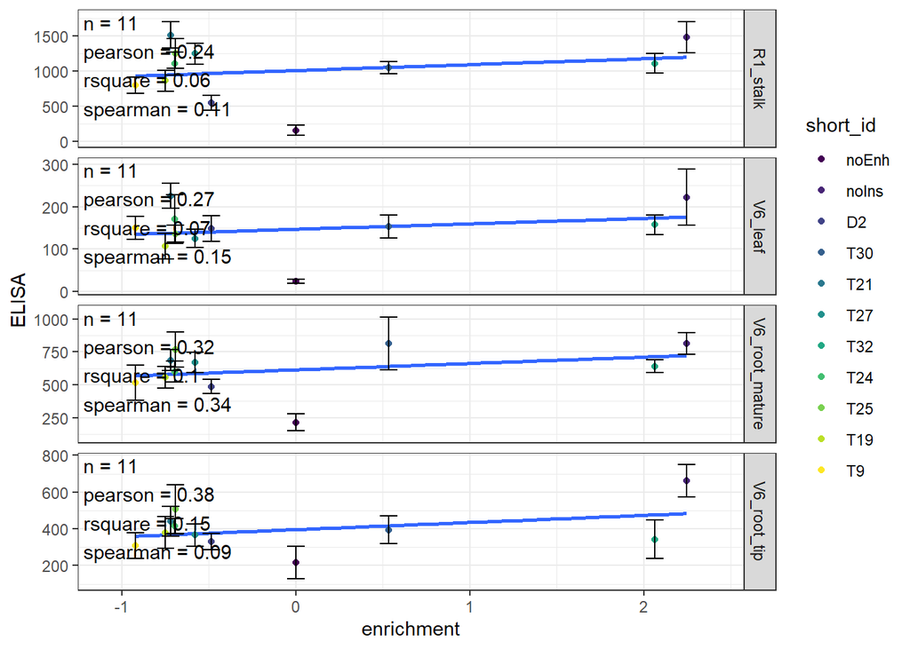

```r
# plot for other tissues/developmental stages
data_ELISA_iFC_summary |>
  filter(sample != 'R1_leaf') |>
  pggfplot(
    filename = 'ELISA_stacked_cor_samples',
    x = enrichment,
    y = ELISA,
    facet_row = sample,
    scales = 'free_y'
  ) |>
  pggf_trendline() |>
  pggf_scatter(
    color = short_id,
    y_error = CI
  ) |>
  pggf_stats(!! pggf_stat_fns$correlation)
```

Calculate correlation between insulator activity in various tissues and compare with Plant STARR-seq:

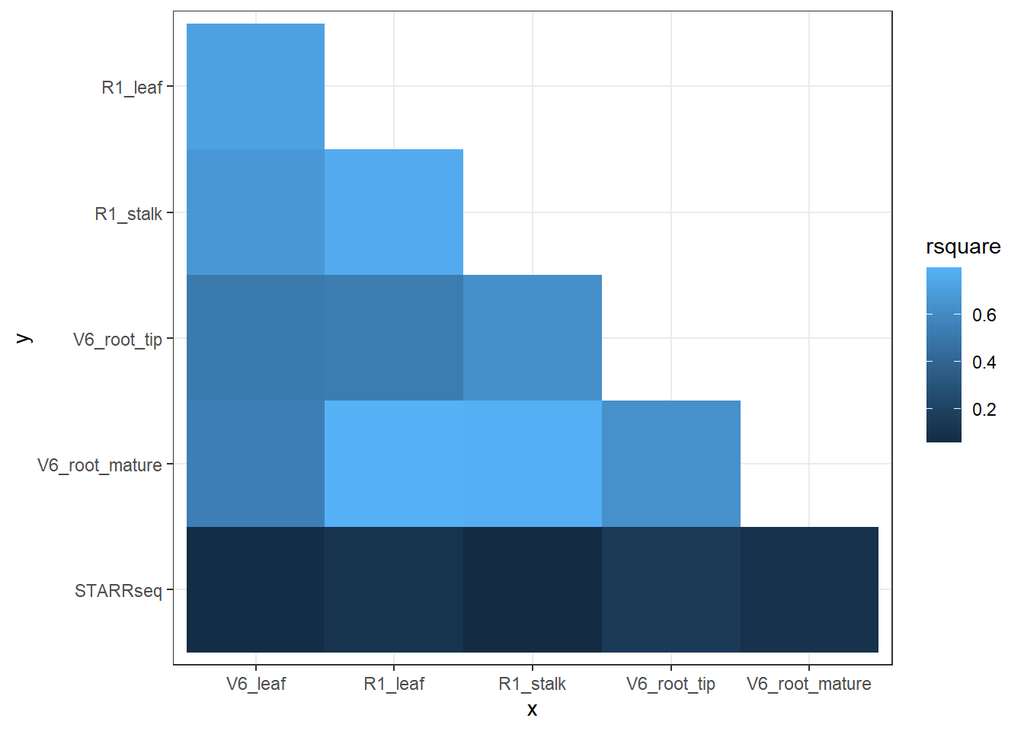

```r
sample_order <- c('V6_leaf', 'R1_leaf', 'R1_stalk', 'R1_husk', 'R1_silk', 'V6_root_tip', 'V6_root_mature', 'STARRseq')

ELISA_cor <- data_ELISA_iFC_summary |>
  select(id, sample, 'STARRseq' = enrichment, ELISA) |>
  pivot_wider(names_from = sample, values_from = ELISA) |>
  select(any_of(sample_order)) |>
  cor(use = 'complete.obs')

ELISA_cor[! lower.tri(ELISA_cor)] <- NA

ELISA_cor |>
  as_tibble(rownames = 'y') |>
  pivot_longer(
    -y,
    names_to = 'x',
    values_to = 'cor'
  ) |>
  mutate(
    across(c(x, y), ~ ordered(.x, levels = sample_order)),
    rsquare = cor^2
  ) |>
  drop_na(rsquare) |>
  pggfplot(
    filename = 'ELISA_stacked_tissues',
    x = x,
    y = y
  ) |>
  pggf_heatmap(
    color = rsquare
  )
```

## Downstream enhancers

Since the distance to the minimal promoter seems to affect the activity of the insulator fragments, we tested if they can still function when we insert a second enhancer between the insulator fragments and the minimal promoter. This gave rise to the **iDE** library. As for previous libraries, replicate correlations were high for this library.

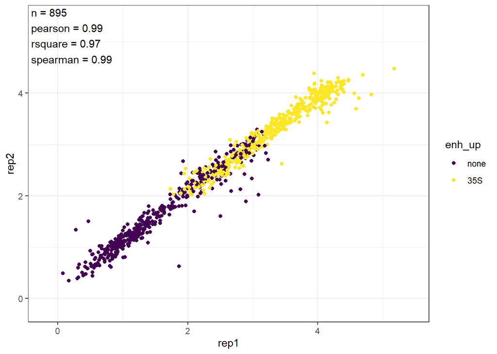

```r
data_iDE_norm |>
  select(rep, sys, enh_up, enh_down, insulator, start, stop, orientation, enrichment) |>
  filter(enh_down != 'none') |>
  pivot_wider(
    names_from = rep,
    names_prefix = 'rep',
    values_from = enrichment
  ) |>
  drop_na(starts_with('rep')) |>
  pggfplot(
    filename = 'iDE_cor_rep',
    x = rep1,
    y = rep2,
    scales = 'square'
  ) |>
  pggf_scatter(color = enh_up) |>
  pggf_stats(!! pggf_stat_fns$correlation)
```

Insulator fragments reduce the enrichment of the reporter construct with and without the upstream 35S enhancer.

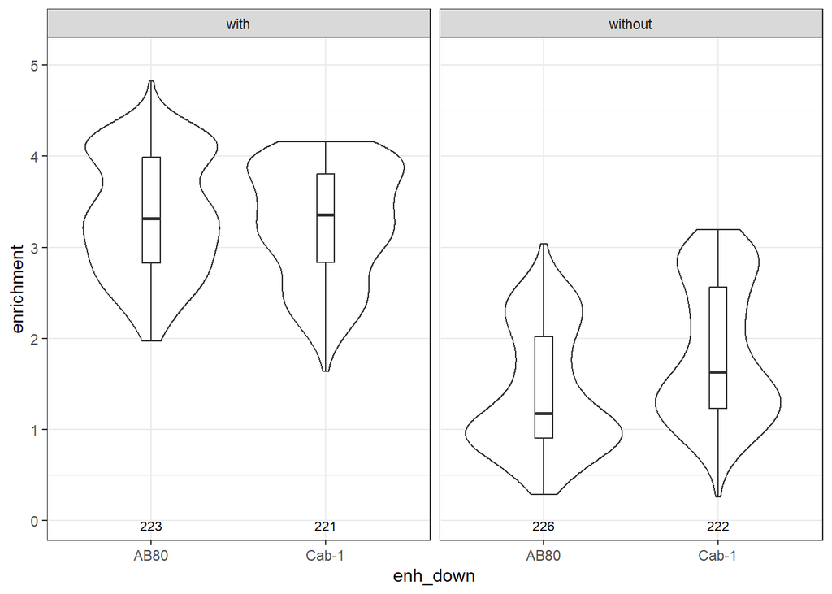

```r
data_iDE_mean |>
  filter(enh_down != 'none') |>
  group_by(enh_up, enh_down) |>
  mutate(
    noIns = enrichment[insulator == 'noIns']
  ) |>
  ungroup() |>
  filter(! insulator %in% c('noEnh', 'noIns')) |>
  mutate(
    enh_up = if_else(enh_up == '35S', 'with', 'without'),
    enh_up = ordered(enh_up, levels = c('with', 'without'))
  ) |>
  pggfplot(
    filename = 'iDE_enrichment',
    x = enh_down,
    y = enrichment,
    facet_col = enh_up
  ) |>
  pggf_violin(
    extra_cols = noIns
  )
```

Insulator activity is similar with and without the downstream enhancer.

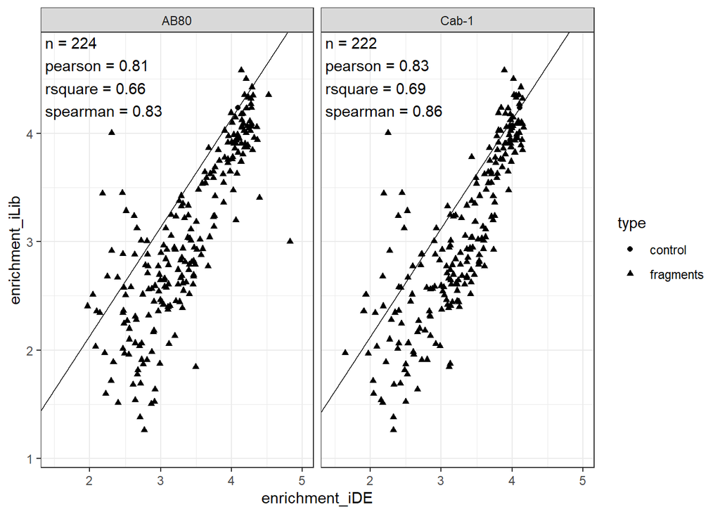

```r
data_iDE_mean |>
  filter(enh_up == '35S' & enh_down != 'none') |>
  select(insulator, start, stop, orientation, enh_down, enrichment) |>
  inner_join(
    data_iLib_mean |>
      filter(sys == 'tobacco' & enhancer == '35S') |>
      select(insulator, start, stop, orientation, enrichment),
    by = c('insulator', 'start', 'stop', 'orientation'),
    suffix = c('_iDE', '_iLib')
  ) |>
  drop_na(starts_with('enrichment')) |>
  mutate(
    type = if_else(insulator == 'noIns', 'control', 'fragments'),
  ) |>
  pggfplot(
    filename = 'iDE_cor_iLib',
    x = enrichment_iDE,
    y = enrichment_iLib,
    facet_col = enh_down
  ) |>
  pggf_scatter(
    split = type
  ) |>
  pggf_stats(!! pggf_stat_fns$correlation) |>
  pggf_abline(intercept = y[type == 'control'] - x[type == 'control'])
```

Insulator fragments have a similar effect on enrichment with and without an upstream 35S enhancer.

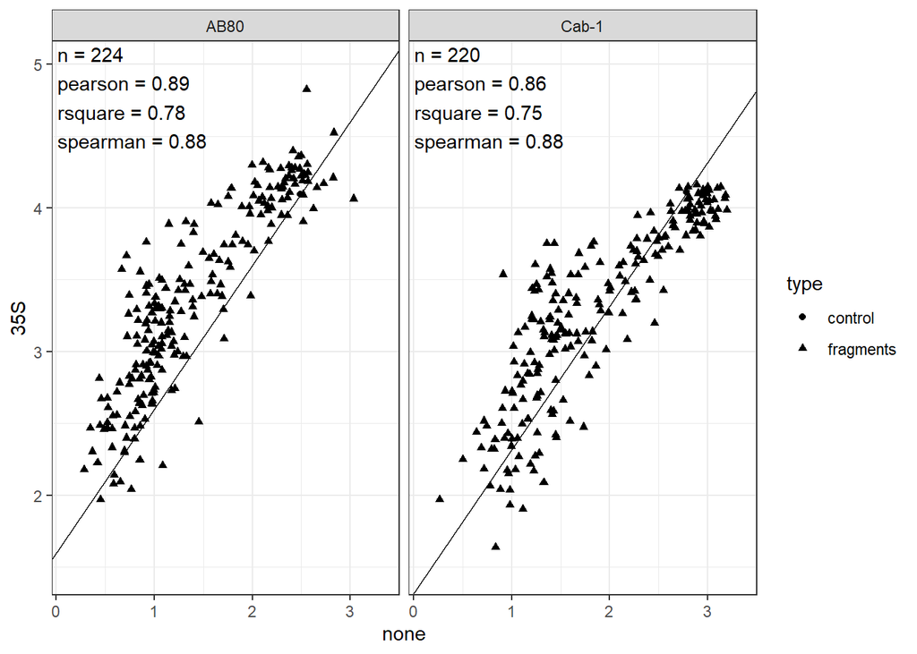

```r
data_iDE_mean |>
  filter(enh_down != 'none') |>
  select(enh_up, enh_down, insulator, start, stop, orientation, enrichment) |>
  pivot_wider(
    names_from = enh_up,
    values_from = enrichment
  ) |>
  drop_na(none, `35S`) |>
  mutate(
    type = if_else(insulator == 'noIns', 'control', 'fragments'),
  ) |>
  pggfplot(
    filename = 'iDE_cor_35S',
    x = none,
    y = `35S`,
    facet_col = enh_down
  ) |>
  pggf_scatter(
    split = type
  ) |>
  pggf_stats(!! pggf_stat_fns$correlation) |>
  pggf_abline(intercept = y[type == 'control'] - x[type == 'control'])
```

Export data to a Supplementary Data file:

```r
DS_id <- 3

data_iDE_export <- data_iDE_mean |>
  select(sys, enh_up, enh_down, insulator, start, stop, orientation, enrichment) |>
  pivot_wider(
    names_from = sys,
    values_from = enrichment
  ) |>
  arrange(enh_up, enh_down, insulator, orientation, start) |>
  mutate(
    sequence = str_sub(FLins_seqs[as.character(insulator)], start, stop),
    sequence = if_else(
      orientation == 'rev',
      as.character(Biostrings::reverseComplement(Biostrings::DNAStringSet(replace_na(sequence, 'A')))),
      sequence
    ),
    sequence = replace_na(sequence, '')
  ) |>
  rename('upstream enhancer' = enh_up, 'downstream enhancer' = enh_down) |>
  mutate(
    insulator = str_replace(insulator, 'beta', 'β'),
    insulator = str_replace(insulator, 'lambda', 'λ')
  )

wb <- createWorkbook()

modifyBaseFont(wb, fontSize = 10, fontName = 'Arial')

addWorksheet(wb, sheetName = 'downstream enhancer')

writeData(
  wb,
  sheet = 1,
  paste0('Supplementary Dataset S', DS_id,'. Enrichment of insulator fragment constructs with a downstream enhancer.'),
  startCol = 1,
  startRow = 1
)

makeNameBold(wb, DS_id)
mergeCells(wb, sheet = 1, rows = 1, cols = seq_len(ncol(data_iDE_export)))

writeData(
  wb,
  sheet = 1,
  paste(
    "Insulator fragments were cloned upstream of a AB80 or Cab-1 enhancer and a 35S minimal promoter driving the expression of a barcoded",
    "GFP reporter gene. Half of the constructs also harbored a 35S enhancer upstream of the insulator fragments while the other half lacked",
    "an upstream enhancer (none). All constructs were pooled and subjected to Plant STARR-seq in N. benthamiana leaves. Reporter mRNA enrichment",
    "was normalized to a control construct without an enhancer or insulator (noEnh; log2 set to 0)."
  ),
  startCol = 1,
  startRow = 2
)

addStyle(wb, sheet = 1, style = xlsx_wrap, rows = 2, cols = 1)
mergeCells(wb, sheet = 1, rows = 2, cols = seq_len(ncol(data_iDE_export)))
setRowHeights(wb, sheet = 1, rows = 2, heights = 12.75 * 5)

xlsx_header <- names(data_iDE_export)
enrichment_ids <- which(xlsx_header %in% c('tobacco', 'maize'))
xlsx_header[enrichment_ids] <- 'log2(enrichment)'

writeData(
  wb,
  sheet = 1,
  matrix(xlsx_header, nrow = 1),
  startCol = 1,
  startRow = 4,
  colNames = FALSE
)

addStyle(wb, sheet = 1, style = xlsx_boldwrap, cols = seq_along(xlsx_header), rows = 4)

writeData(
  wb,
  sheet = 1,
  data_iDE_export,
  startCol = 1,
  startRow = 5,
  headerStyle = xlsx_bold,
  keepNA = TRUE
)

mergeCells(wb, sheet = 1, rows = 4, cols = enrichment_ids)
addStyle(wb, sheet = 1, style = xlsx_center, rows = 4, cols = enrichment_ids, stack = TRUE)

for (i in seq_along(xlsx_header)[-enrichment_ids]) {
  mergeCells(wb, sheet = 1, rows = 4:5, cols = i)
}

addStyle(wb, sheet = 1, style = xlsx_2digit, cols = enrichment_ids, rows = 6:(nrow(data_iDE_export) + 6), gridExpand = TRUE)
addStyle(wb, sheet = 1, style = xlsx_seq_font, cols = which(xlsx_header == 'sequence'), rows = 6:(nrow(data_iDE_export) + 6))

setColWidths(wb, sheet = 1, cols = which(xlsx_header == 'downstream enhancer'), widths = 11.5)
setColWidths(wb, sheet = 1, cols = which(xlsx_header == 'log2(enrichment)'), widths = 16)

freezePane(wb, sheet = 1, firstActiveRow = 6)

saveWorkbook(wb, paste0(supp_data_dir, 'SupplementaryDataset', DS_id, '.xlsx'), overwrite = TRUE)
```